# Peer Assesment Project 1 - Reproducible Research [Coursera repdata-016]

## Carlos E. Martinez-Torteya - December 12, 2014

### Introduction

In this project we will use data collected from a personal monitoring device that collected the number of steps taken in 5-minute intervals each day for a two month period.

First, we load the data set and take a quick look at its contents:

```r
library(ggplot2)
rawdata <- read.csv("activity.csv")
head(rawdata)
```

```
##   steps       date interval
## 1    NA 2012-10-01        0
## 2    NA 2012-10-01        5
## 3    NA 2012-10-01       10
## 4    NA 2012-10-01       15
## 5    NA 2012-10-01       20
## 6    NA 2012-10-01       25
```

It is immediately clear that the raw data set contains some NA's. For the first part of the project, we will work with only the non-NA data:

```r
completedata <- rawdata[complete.cases(rawdata),]
str(completedata)
```

```
## 'data.frame':    15264 obs. of  3 variables:
##  $ steps   : int  0 0 0 0 0 0 0 0 0 0 ...
##  $ date    : Factor w/ 61 levels "2012-10-01","2012-10-02",..: 2 2 2 2 2 2 2 2 2 2 ...
##  $ interval: int  0 5 10 15 20 25 30 35 40 45 ...
```

As the dates were read as *factors*, and we will be using dates for subsetting and plotting, we should convert the date values from *factors* to *dates*. Also, we will convert the steps value from *integer* to *numeric* to avoid problems with calculations:

```r
completedata$date <- as.Date(as.character(completedata$date))
completedata$steps <- as.numeric(completedata$steps)
str(completedata)
```

```
## 'data.frame':    15264 obs. of  3 variables:
##  $ steps   : num  0 0 0 0 0 0 0 0 0 0 ...
##  $ date    : Date, format: "2012-10-02" "2012-10-02" ...
##  $ interval: int  0 5 10 15 20 25 30 35 40 45 ...
```

### What is mean total number of steps taken per day?

One can calculate the total number of steps taken each day in a number of different ways. Here, we will use *tapply*:

```r
datesums <- tapply(completedata$steps, completedata$date, sum)
```

With this, we can now create a histogram of total steps taken per day:

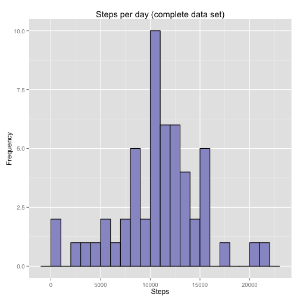

```r
df1 <- data.frame(steps=datesums)
h <- ggplot(df1, aes(x=steps)) + geom_histogram(bin=1000, fill="#9999CC", color="black") + ggtitle("Steps per day (complete data set)")+xlab("Steps")+ylab("Frequency")
plot(h)
```

Also, we can now quickly obtain the mean and median number of steps per day using *summary*, taking care to use an adequate value for the *digits* option (number of significant figures used in calculations):

```r
round(summary(datesums, digits=7))
```

```
##    Min. 1st Qu.  Median    Mean 3rd Qu.    Max.
##      41    8841   10765   10766   13294   21194
```

Or we could calculate them directly, using the *mean* and *median* functions:

```r
datesums_mean <- mean(datesums)
round(datesums_mean)
```

```
## [1] 10766
```

```r
datesums_median <- median(datesums)
round(datesums_median)
```

```
## [1] 10765
```

### What is the average daily activity pattern?

Now we follow a similar procedure, but summing steps over interval instead of date. First, we take a quick look at the *interval* values:

```r
head(unique(completedata$interval), 20)
```

```
##  [1]   0   5  10  15  20  25  30  35  40  45  50  55 100 105 110 115 120
## [18] 125 130 135
```

Where we note that the interval contains the 5-minute span when the number of steps were counted (e.g. “50” stands for 00:50, “135” for 01:35, “1630” for 16:30, etc.).

Again, we will use *tapply* to obtain the average number of steps taken during each interval, and take a look at a summary of it:

```r
intervalave <- tapply(completedata$steps, completedata$interval, mean, simplify = TRUE)
round(summary(intervalave, digits=7))
```

```
##    Min. 1st Qu.  Median    Mean 3rd Qu.    Max.
##       0       2      34      37      53     206
```

Although technically we averaged over number of intervals, as all days contain equal number of intervals in the *completedata* set (which will be shown explicitely in a later section), this is equivalent to averaging over number of days.

Now, we generate a time-series plot for number of steps Vs time interval.

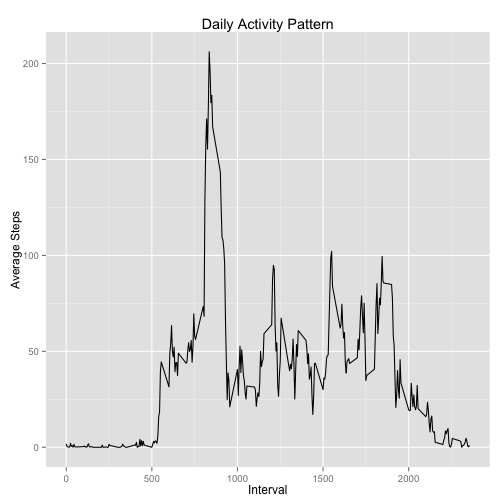

```r
df2 <- data.frame(interval=unique(completedata$interval), ave_step=intervalave)
k <- ggplot(df2, aes(x=interval, y=ave_step)) + geom_line() + xlab("Interval") + ylab("Average Steps") + ggtitle("Daily Activity Pattern")
plot(k)
```

From the plot, it is clear that the maximum occurs sometime between 7AM and 9AM. We obtain the exact 5-minute interval when this occurs:

```r
which(intervalave == max(intervalave))
```

```
## 835
## 104
```

So, *on average* the 5-minute interval starting at **08:35AM** (the 104th interval in the dataset) was the one when the most steps were taken, with a daily average of 206 steps.